# Summary of Half of Lesson 3 from Data Analysis with R

Mingyu Lee

Wednesday, September 02, 2015

# 3장에서 배울 내용

- 한 데이터 세트의 단일 변수 조사 방법
- 히스토그램과 시각화와 관련 R 명령어
- 데이터에 접근하는 방법

# 먼저 해야할 것은?

- 탐색적 데이터 분석에 앞서, 연구의 목적을 돌이켜보고
- **구하고자 하는 답에 대한 질문이 무엇인가?** 상기
- 연구에서 가장 중요한 변수를 이해하기 위해서
- 그 개별 변수들에 대한 요약과 시각화를 만드는 형태를 취할 것이다.

# 가상 페이스북 유저데이터

- 이번 3장에서는 가상의 페이스북 유저 데이터를 이용한다.
- 강의 노트에서 *pseudo-facebook.tsv*를 다운 받는다.
- `getwd()` 명령어로 R에 설정된 현재 홈 디렉토리를 확인한다.
- `setwd("주소")` 명령어로 홈 디렉토리를 설정할 수 있다.
- **주의사항** 주소 경로는 ‘/’ 로 구분한다.

```r
setwd("C:/Users/Mingyu/workspace/3. R/Data Analysis with R_Udacity/Lesson 3")
getwd()
```

```
## [1] "C:/Users/Mingyu/workspace/3. R/Data Analysis with R_Udacity/Lesson 3"
```

```r
list.files()
```

```
## [1] "presentation_lesson3-copy.html" "presentation_lesson3-copy.md"
## [3] "presentation_lesson3-copy.Rmd"  "pseudo_facebook.tsv"
```

- `list.files()` 명령어로 홈 디렉토리 내의 파일 목록을 확인한다.
- `read.csv()` 명령어로 *pseudo-facebook.tsv*를 불러온다.

```r
pf <- read.csv('pseudo_facebook.tsv', sep ='\t')
```

- `\t` 으로 구분하고, 불러온 데이터를 *pf* 변수에 담는다는 의미이다.

# 데이터세트 컬럼 확인하기

`names(pf)` 명령어로 pf 변수에 담긴 데이터세트의 컬럼 정보를 확인 할 수 있다.

```r
names(pf)
```

```
##  [1] "userid"                "age"
##  [3] "dob_day"               "dob_year"
##  [5] "dob_month"             "gender"
##  [7] "tenure"                "friend_count"
##  [9] "friendships_initiated" "likes"
## [11] "likes_received"        "mobile_likes"
## [13] "mobile_likes_received" "www_likes"
## [15] "www_likes_received"
```

# ggplot2을 이용한 히스토그램 작성

- `install.packages("ggplot2")` 명령어로 ggplot2 패키지ㄹ 설치한다.
- 설치가 완료되면 `library(ggplot2)` 명령어로 ggplot2 패키지를 로드한다.
- 위에서 가상의 페이스북 데이터세트를 담고 있는 pf를 통해 히스토그램을 만들어보자.
- `qplot()` 명령어를 사용한다
- `qplot()`은 Quick plot의 약자로 ggplot2 패키지의 가장 기본적인 도표 작성 기능이다.

```
## stat_bin: binwidth defaulted to range/30. Use 'binwidth = x' to adjust this.
```

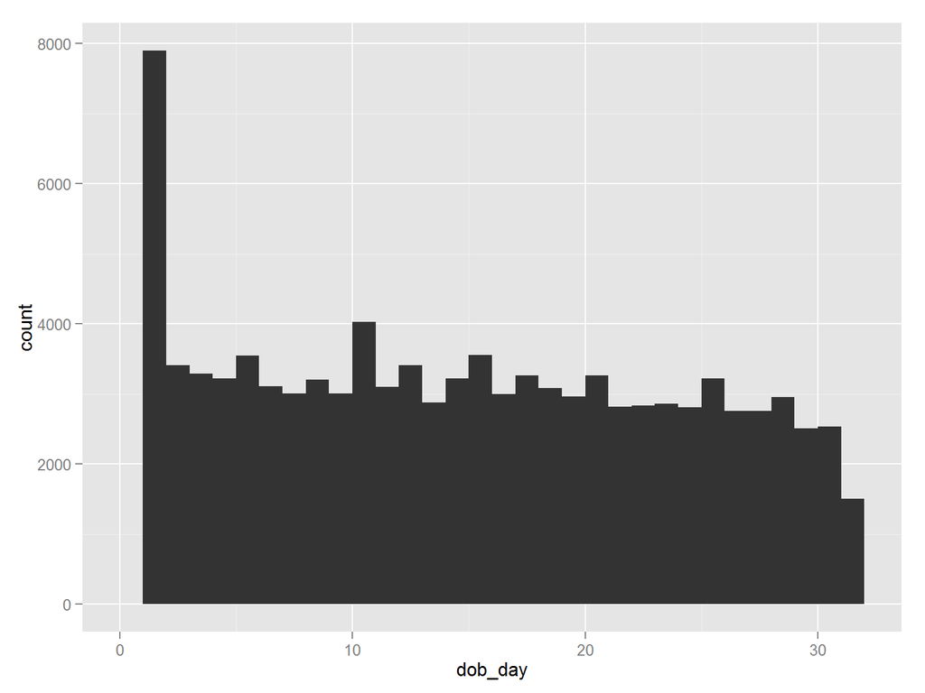

```r
library(ggplot2)
qplot(x = dob_day, data = pf)
```

- `qplot()`의 인자 중 *x*는 dob_day 변수의 데이터를 가져오고, *data*는 pf 데이터 세트를 가져온다는 의미이다.

# 정확한 히스토그램 작성

- 일수는 1~31일인데, 히스토그램은 10단위로 뭉뚱그려 표시되므로 직관적이지 못하고 에러메시지 발생.
- 에러메시지: **stat_bin: binwidth defaulted to range/30. Use ‘binwidth = x’ to adjust this.**
- x 축의 단위를 수정해보자

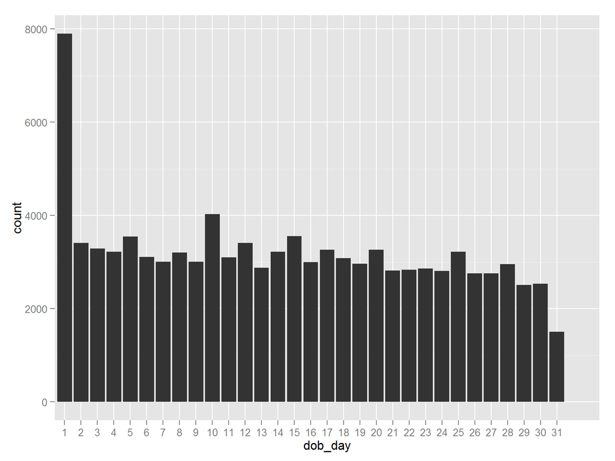

```r
qplot(x = dob_day, data = pf) + scale_x_discrete(breaks = 1:31)
```

# (번외)히스토그램 꾸미기: ggthemes

- `ggthemes()` 패키지를 사용하여 ggplot 패키지로 생성하는 도표들을 간단하게 꾸밀 수 있다.

```r
install.packages('ggthemes', dependencies = TRUE)
## 또는
library("devtools")
install_github("jrnold/ggthemes")
## 사용법 예제
qplot(x = dob_day, data = pf) + geom_histogram() + theme_wsj() +ggtitle("Day of Birth of Facebook users") + scale_x_discrete(breaks = 1:31)
```